# Lab 019 — When trees win: see the three inductive biases move

## Follow the computation

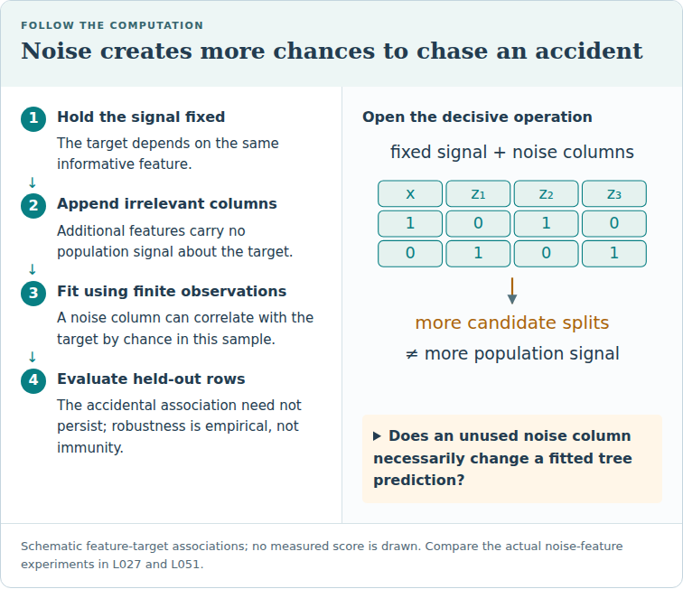

Schematic feature-target associations; no measured score is drawn. Compare the actual noise-feature experiments in L027 and L051.

**Trace question:** Does an unused noise column necessarily change a fitted tree prediction?

**Trace answer:** No. The point is the opportunity for a spurious selected split, not a claim that every appended column changes every tree.

**Lesson:** `lessons/0019-when-trees-win.html` · **Phase / Year:** Year 1 · Q2

**Paper (preview):** Grinsztajn, Oyallon & Varoquaux 2022, *Why do tree-based models still outperform deep learning on typical tabular data?*, [arXiv:2207.08815](https://arxiv.org/abs/2207.08815) — abstract + §1 (the three challenges); §5 (the controlled experiments you reproduce in miniature here).

**Dataset tier:** C — synthetic (mechanism isolation). Each experiment turns exactly one knob so a single bias is visible in isolation; this is *not* a benchmark.

**Skill you are practising:** construct the three controlled experiments (an irregular target, a pile of uninformative features, a random rotation) and read off *why* a tree beats a plain neural net on each — then state the three tree strengths in your own words.

**Exit criteria:** EXIT TICKET prints (1) tree vs MLP accuracy across checkerboard frequencies, (2) the tree/MLP gap as noise features grow, (3) tree vs MLP before/after a random rotation, plus your one-line-each statement of the three biases.

### How this notebook works

- **PROVIDED** cells — complete boilerplate; just run.
- **TODO** cells — blanks (`____` / `# TODO`); you implement the skill.
- **CHECK** cells — immediate feedback; do not edit.
- Run top to bottom. When **EXIT TICKET** prints cleanly, paste it to your teacher or say *"lab done"*.

### Environment

One-time: `bash labs/setup-env.sh` from repo root → kernel **Relational Labs (.venv)**. Needs **scikit-learn** and **numpy** only (no boosters here). No local install? Open from `notebooks.html` — **View** to read it rendered, or **Run on Binder**.

### Running on Google Colab?

Colab opens only this single file, so the course package (`relkit`) and the lab dependencies (xgboost, lightgbm, catboost, …) are **not** present by default. The cell below fixes that: on Colab it shallow-clones the course repo, installs `requirements-labs.txt`, and switches into `labs/` so `relkit` imports and the data cache resolve. **On a local venv or Binder it does nothing — just run it and continue.**

```python
# @colab-bootstrap — PROVIDED. Makes the lab self-sufficient on Google Colab; a no-op elsewhere.
import os, sys

if "google.colab" in sys.modules:
    if not os.path.isdir("/content/relational"):
        !git clone --depth 1 https://github.com/Avistian/relational.git /content/relational
    %pip install -q -r /content/relational/requirements-labs.txt
    os.chdir("/content/relational/labs")
    print("Colab ready — working dir:", os.getcwd())
else:
    print("Not on Colab — using the local environment as-is.")
```

## Concept recap — three biases, one knob each

Every learner has an **inductive bias** — the kind of function it reaches for first. A neural net (MLP) is biased toward **smooth** functions; a decision tree toward **axis-aligned, piecewise-constant** ones. Neither is universally better — what matters is whether the bias *matches the data*. Grinsztajn et al. (2022) found tree-based models still beat deep nets on typical ~10K-row tabular data, and isolated three reasons. This lab reproduces each in miniature with a **RandomForest** (the tree) vs a **2×256 MLP** (the net), scored by test accuracy.

**1. Irregular targets.** Tabular targets often jump at thresholds (a fee at 30 days late). A tree places a hard step anywhere; a smooth-biased net rounds it off. We make the target progressively rougher with a **checkerboard**: split each axis into $t$ tiles and label a point by the parity of its tile, $$y = \left(\lfloor t\,x_0 \rfloor + \lfloor t\,x_1 \rfloor\right) \bmod 2.$$ Bigger $t$ = finer, more irregular target.

**Toy micro-example (not this lab's answer).** Target $y = \mathbb{1}[x > 3]$ on $x \in \{1,2,3,4,5\}$ → labels $0,0,0,1,1$. A tree needs *one* split at $x=3.5$ to be perfect. A smooth line through those points must slope gently and will be wrong near the jump — the smoothness bias in one picture.

Full write-up + the interactive checkerboard/rotation widget: Lesson 019.

## Setup — PROVIDED

```python
# PROVIDED — models + a scorer. Same RandomForest (tree) and MLP (net) throughout.
import warnings
warnings.filterwarnings("ignore")

import numpy as np
from sklearn.ensemble import RandomForestClassifier
from sklearn.metrics import accuracy_score
from sklearn.model_selection import train_test_split
from sklearn.neural_network import MLPClassifier
from sklearn.pipeline import make_pipeline
from sklearn.preprocessing import StandardScaler
from sklearn.datasets import make_classification

RS = 0
rng = np.random.RandomState(RS)

def tree():
    return RandomForestClassifier(n_estimators=300, n_jobs=4, random_state=RS)

def nn():
    return make_pipeline(
        StandardScaler(),
        MLPClassifier(hidden_layer_sizes=(256, 256), alpha=1e-4,
                      max_iter=400, early_stopping=True, random_state=RS),
    )

def score(model_fn, X, y):
    Xtr, Xte, ytr, yte = train_test_split(X, y, test_size=0.3, random_state=RS, stratify=y)
    m = model_fn().fit(Xtr, ytr)
    return accuracy_score(yte, m.predict(Xte))

print("tree + nn + scorer ready")
```

## Task 1 — irregular targets: the checkerboard — TODO (crucial fragment)

**Goal:** build a checkerboard target of frequency $t$ and score the tree vs the MLP as $t$ rises.

**Why it matters:** this is Grinsztajn's smoothness finding in one experiment — as the target gets rougher, the smooth-biased net falls behind while the tree keeps carving cells.

**You implement:** the checkerboard label. For points `X` in the unit square and `t` tiles per side, a point's tile index on an axis is `np.floor(t * X[:, axis])`; the label is the **parity** (mod 2) of the sum of the two tile indices. Cast to `int`.

**Hint boundary:** use `np.floor`, integer cast, and `% 2`. Do not change the loop or the models.

```python
# TODO — implement the checkerboard label
def checkerboard(t, n=6000, seed=RS):
    r = np.random.RandomState(seed)
    X = r.uniform(0, 1, size=(n, 2))
    y = ____            # parity (mod 2) of the sum of the two tile indices floor(t*x); cast to int
    return X, y

irr = {}
for t in (2, 4, 8, 16):
    X, y = checkerboard(t)
    irr[t] = (score(tree, X, y), score(nn, X, y))
    print(f"  {t:2d}x{t:<2d} ({t*t:3d} cells): tree {irr[t][0]:.3f}  nn {irr[t][1]:.3f}  gap {irr[t][0]-irr[t][1]:+.3f}")
```

```python
# CHECK — do not edit
assert set(np.unique(list(checkerboard(4)[1]))) == {0, 1}, "Checkerboard labels must be 0/1."
assert irr[2][0] > 0.95 and irr[2][1] > 0.95, "At 2x2 both models should be near-perfect."
assert irr[8][0] - irr[8][1] > 0.05, "By 8x8 the tree should clearly lead the smooth-biased net."
assert (irr[16][0] - irr[16][1]) > (irr[2][0] - irr[2][1]), "The gap should GROW as the target gets more irregular."
print(f"Task 1 ok — gap widens {irr[2][0]-irr[2][1]:+.3f} (2x2) -> {irr[16][0]-irr[16][1]:+.3f} (16x16). "
      f"Irregular targets favour the tree.")
```

## Task 2 — robustness to uninformative features — TODO (crucial fragment)

**Goal:** start from an informative 10-feature task and append growing numbers of pure-noise columns; compare how fast the tree vs the MLP degrades.

**Why it matters:** a tree ignores junk (implicit feature selection); an MLP does not. This is why trees shine on wide real tables full of weak/dead columns — *but note the honest twist in row `k=0`.*

**You implement:** append `k` columns of standard Gaussian noise to the base matrix `Xb`. Use the PROVIDED `rng` so it is reproducible, and `np.hstack` to concatenate.

**Hint boundary:** `rng.normal(size=(n_rows, k))` makes the junk; `np.hstack([...])` glues it to `Xb`. When `k == 0`, just use `Xb` unchanged.

```python
# PROVIDED — one fixed informative task; we only add junk columns to it.
Xb, yb = make_classification(n_samples=6000, n_features=10, n_informative=10,
                             n_redundant=0, n_repeated=0, n_clusters_per_class=2,
                             class_sep=1.0, flip_y=0.02, random_state=RS)
print("base task:", Xb.shape)
```

```python
# TODO — add k noise features, then score both models
def add_noise(k):
    if k == 0:
        return Xb
    return ____        # np.hstack Xb with an (n_rows x k) block of rng.normal noise

junk = {}
for k in (0, 20, 50, 100):
    Xj = add_noise(k)
    junk[k] = (score(tree, Xj, yb), score(nn, Xj, yb))
    print(f"  +{k:3d} noise ({10+k:3d} feats): tree {junk[k][0]:.3f}  nn {junk[k][1]:.3f}  gap {junk[k][0]-junk[k][1]:+.3f}")
```

```python
# CHECK — do not edit
assert add_noise(20).shape == (Xb.shape[0], 30), "add_noise(20) should give 10 + 20 = 30 columns."
assert junk[0][1] >= junk[0][0] - 0.005, "Honest twist: with no junk the MLP should be competitive/better."
assert (junk[100][0] - junk[100][1]) > (junk[0][0] - junk[0][1]), "The tree should get RELATIVELY better as junk grows."
nn_drop = junk[0][1] - junk[100][1]
tree_drop = junk[0][0] - junk[100][0]
assert nn_drop > tree_drop, "The MLP should lose more accuracy to junk than the tree does."
print(f"Task 2 ok — junk cost the MLP {nn_drop:.3f} but the tree only {tree_drop:.3f}. "
      f"Trees are robust to uninformative features.")
```

## Task 3 — orientation: a random rotation — TODO (crucial fragment)

**Goal:** take an axis-aligned XOR target, apply a **random orthogonal rotation**, and show the tree collapses while the (rotation-invariant) MLP does not.

**Why it matters:** this is the sharpest evidence in the paper. A tree exploits the fact that individual columns are meaningful (axis-aligned splits); rotating mixes the columns into meaningless combinations, and the tree's edge vanishes. An MLP is ~rotation-invariant, so it is unmoved — which on tables is a *weakness*, not a virtue.

**You implement:** a random orthogonal matrix `Q` and the rotated design `Xrot = Xr @ Q`. Get an orthogonal `Q` from the **QR decomposition** of a random Gaussian matrix: `np.linalg.qr(rng.normal(size=(d, d)))` returns `(Q, R)`.

**Hint boundary:** build a `(d, d)` Gaussian matrix with `rng.normal`, take `Q` from `np.linalg.qr(...)`, then matrix-multiply `Xr @ Q`. `d` is the number of columns of `Xr`.

```python
# PROVIDED — axis-aligned XOR on 2 features + 6 pure-noise features.
d = 8
Xr = rng.normal(size=(6000, d))
yr = ((Xr[:, 0] > 0) ^ (Xr[:, 1] > 0)).astype(int)   # XOR of two axis-aligned thresholds
print("XOR task:", Xr.shape, "positives:", int(yr.sum()))
```

```python
# TODO — rotate the feature space, then compare orig vs rotated
A = ____                        # a (d, d) matrix of Gaussian noise (use rng)
Q, _ = ____                     # orthogonal Q from the QR decomposition of A
Xrot = ____                     # rotate the design: X @ Q

rot = {"original": (score(tree, Xr, yr),   score(nn, Xr, yr)),
       "rotated":  (score(tree, Xrot, yr), score(nn, Xrot, yr))}
for k, (t, n_) in rot.items():
    print(f"  {k:9s}: tree {t:.3f}  nn {n_:.3f}")
print(f"  rotation cost -> tree {rot['original'][0]-rot['rotated'][0]:+.3f}   nn {rot['original'][1]-rot['rotated'][1]:+.3f}")
```

```python
# CHECK — do not edit
assert np.allclose(Q @ Q.T, np.eye(d), atol=1e-8), "Q must be orthogonal (a rotation)."
assert np.allclose(Xrot, Xr @ Q), "Xrot should be the rotated design X @ Q."
assert rot["original"][0] > 0.9, "Axis-aligned, the tree should nail the XOR."
assert (rot["original"][0] - rot["rotated"][0]) > 0.1, "Rotation should clearly hurt the tree."
assert abs(rot["original"][1] - rot["rotated"][1]) < 0.03, "Rotation should barely move the ~invariant MLP."
print(f"Task 3 ok — rotation dropped the tree by {rot['original'][0]-rot['rotated'][0]:.3f} "
      f"but the MLP by only {abs(rot['original'][1]-rot['rotated'][1]):.3f}. Orientation was the tree's edge.")
```

## Exit ticket — TODO

**Goal:** one printed summary to paste back to your teacher.

**Takeaway prompt:** name the three tree strengths (inductive biases) in your own words, in one sentence each.

```python
# TODO: complete the three-strengths string
print("=== EXIT TICKET — Lesson 019 ===")
print(f"1. Irregular target : 2x2 gap {irr[2][0]-irr[2][1]:+.3f} -> 16x16 gap {irr[16][0]-irr[16][1]:+.3f}")
print(f"2. Uninformative    : +0 gap {junk[0][0]-junk[0][1]:+.3f} -> +100 gap {junk[100][0]-junk[100][1]:+.3f}")
print(f"3. Orientation      : tree {rot['original'][0]:.3f}->{rot['rotated'][0]:.3f}, nn {rot['original'][1]:.3f}->{rot['rotated'][1]:.3f}")
print()
print("three tree strengths:", "____")
```

## Stretch (optional, ungraded) — push the biases

1. **Smooth it back.** Replace the checkerboard with a *smooth* target, e.g. $y = \mathbb{1}[x_0 + x_1 > 1]$. The tree's edge should shrink toward the MLP — confirming the edge lives in the *non-smooth* regime.
2. **Rotate only the informative axes.** Rotate just columns 0–1 of the XOR task and leave the noise columns alone — does a partial rotation cost the tree less?
3. **A modern tabular net.** Swap the MLP for `sklearn.ensemble.HistGradientBoostingClassifier` (another tree) on the rotated task — two trees, same rotation weakness. (The Year-2 architectures fix this on purpose.)

```python
# STRETCH — ungraded.
# def smooth(n=6000, seed=RS):
#     r = np.random.RandomState(seed); X = r.uniform(0, 1, size=(n, 2))
#     return X, (X[:, 0] + X[:, 1] > 1).astype(int)
# Xs, ys = smooth()
# print("smooth target: tree", round(score(tree, Xs, ys), 3), " nn", round(score(nn, Xs, ys), 3))
```